# **Easy Visa**

### **📌 Model Performance Summary**

We evaluated three models — **Decision Tree**, **Bagging Classifier**, and **Random Forest** — across the original, oversampled, and undersampled datasets. Below is a detailed analysis of their performance:

1. **Decision Tree**
   - Shows signs of overfitting on all datasets.
   - **Generalization** is slightly better with the **oversampled dataset**, as it balances recall and precision more effectively.
   - **Best F1 Performance** is achieved with **oversampling**, making it a preferable choice.
2. **Bagging Classifier**
   - More stable compared to the Decision Tree, reducing overfitting.
   - **Generalizes best** with the **original dataset**, maintaining strong recall and precision without excessive variance.
   - **Best F1 Performance** is also with the **original dataset**, making it the most reliable option.
3. **Random Forest**
   - Consistently the strongest performer across all datasets.
   - **Generalizes best** with the **original dataset**, striking a balance between recall and precision.
   - **Best F1 Performance** is also observed with **original dataset**, reinforcing its robustness.

### **🏆 Selecting the Best Dataset for Each Model**

✔ **Decision Tree → `Oversampled Data`** (Better generalization & F1 score)  
✔ **Bagging Classifier → `Original Data`** (Strong balance & generalization)  
✔ **Random Forest → `Original Data`** (Best F1 & most reliable)

#### 🚀 **Next Steps**

- Fine-tune each model on its respective best-performing dataset.
- Optimize hyperparameters to further improve F1 and generalization.

### `1. Tuned Decision Tree On Oversampled Data`

```
Fitting 5 folds for each of 30 candidates, totalling 150 fits
Best Parameters: {'min_samples_split': np.int64(6), 'min_samples_leaf': np.int64(7), 'max_leaf_nodes': 100, 'max_features': None, 'max_depth': 10, 'criterion': 'log_loss', 'ccp_alpha': np.float64(0.02777777777777778)}

---------------------------------

Mean cross-validation f1 score: 0.7958867351478887

---------------------------------

Train Performance:
    Accuracy    Recall  Precision        F1
0  0.717611  0.891215   0.722073  0.797778

---------------------------------

Confusion Matrix for Model Performance on Test Data:

🔎 Observations:

1. True Positives (predicted=1, actual=1): 3016 (59.18%)
2. True Negatives (predicted=0, actual=0): 657 (12.89%)
3. False Positives (predicted=1, actual=0): 1035 (20.31%)
4. False Negatives (predicted=0, actual=1): 388 (7.61%)

---------------------------------

Test Performance:
    Accuracy    Recall  Precision        F1
0  0.720761  0.886016   0.744508  0.809121
```

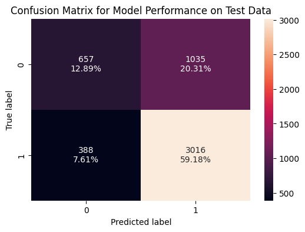

```python
param_dict = {
    'max_depth': [3, 5, 10, 20, None],
    'min_samples_split': np.arange(2, 21, 2),
    'min_samples_leaf': np.arange(1, 21, 2),
    'max_features': ['sqrt', 'log2', None],
    'criterion': ['gini', 'entropy', 'log_loss'],
    'ccp_alpha': np.linspace(0, 0.05, 10),
    'max_leaf_nodes': [None, 10, 20, 50, 100]
}
dt = DecisionTreeClassifier(class_weight="balanced", random_state=1)
tuned_dtree_results = tune_model(param_dict, skfold, dt, X_train_over, y_train_over, X_test, y_test, scoring='f1', n_iter=30)
random_search1_train_perf = tuned_dtree_results['train_performance']
random_search1_test_perf = tuned_dtree_results['test_performance']
```

🔎 **Observations:** The test F1 score is almost equal to the cross-validation mean F1 score, indicating that the model generalizes well. The accuracy of the train set and test set are close, suggesting that the model generalizes well without significant overfitting or underfitting.

### `2. Tuned Bagging Classifier on Original Data`

```
Fitting 5 folds for each of 30 candidates, totalling 150 fits
Best Parameters: {'n_estimators': 100, 'max_samples': 0.5, 'max_features': 1.0, 'estimator__penalty': 'l1', 'estimator__C': np.float64(166.81005372000558), 'bootstrap_features': False, 'bootstrap': True}

---------------------------------

Mean cross-validation f1 score: 0.8180096513446511

---------------------------------

Train Performance:
    Accuracy   Recall  Precision        F1
0  0.740777  0.88005   0.766441  0.819326

---------------------------------

Confusion Matrix for Model Performance on Test Data:

🔎 Observations:

1. True Positives (predicted=1, actual=1): 2962 (58.12%)
2. True Negatives (predicted=0, actual=0): 750 (14.72%)
3. False Positives (predicted=1, actual=0): 942 (18.49%)
4. False Negatives (predicted=0, actual=1): 442 (8.67%)

---------------------------------

Test Performance:
    Accuracy    Recall  Precision        F1
0  0.728414  0.870153   0.758709  0.810619
```

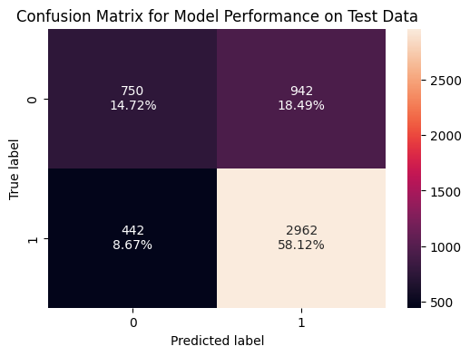

```python
param_dict = {
    'n_estimators': [10, 50, 100, 200, 300],
    'max_samples': [0.5, 0.7, 1.0],
    'max_features': [0.5, 0.7, 1.0],
    'bootstrap': [True, False],
    'bootstrap_features': [True, False],

    # Logistic Regression-specific hyperparameters
    'estimator__C': np.logspace(-4, 4, 10),  # Regularization strength
    'estimator__penalty': ['l1', 'l2', 'elasticnet', None],
}

# Initialize BaggingClassifier with Logistic Regression base estimator
bag2 = BaggingClassifier(estimator=LogisticRegression(solver='liblinear', random_state=1),random_state=1)
tuned_bag2_results = tune_model(param_dict, skfold, bag2, X_train, y_train, X_test, y_test, scoring='f1', n_iter=30)
random_search2_train_perf = tuned_bag2_results['train_performance']
random_search2_test_perf = tuned_bag2_results['test_performance']
```

🔎 **Observations:** The test F1 score is almost equal to the cross-validation mean F1 score, indicating that the model generalizes well. The accuracy of the train set and test set are close, suggesting that the model generalizes well without significant overfitting or underfitting.

### `3. Tuned Random Forest Classifier on Original Data`

```
Fitting 5 folds for each of 30 candidates, totalling 150 fits
Best Parameters: {'n_estimators': 300, 'min_samples_split': np.int64(14), 'min_samples_leaf': np.int64(17), 'max_features': 'sqrt', 'max_depth': 10, 'criterion': 'gini', 'bootstrap': True}

---------------------------------

Mean cross-validation f1 score: 0.8251283916266265

---------------------------------

Train Performance:
    Accuracy   Recall  Precision        F1
0   0.75888  0.89048   0.779765  0.831453

---------------------------------

Confusion Matrix for Model Performance on Test Data:

🔎 Observations:

1. True Positives (predicted=1, actual=1): 3004 (58.95%)
2. True Negatives (predicted=0, actual=0): 757 (14.85%)
3. False Positives (predicted=1, actual=0): 935 (18.35%)
4. False Negatives (predicted=0, actual=1): 400 (7.85%)

---------------------------------

Test Performance:
    Accuracy    Recall  Precision        F1
0   0.73803  0.882491    0.76263  0.818194
```

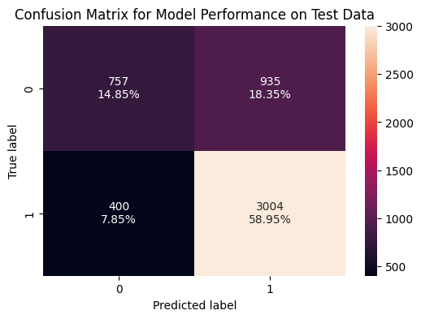

```python
param_dict = {
    'n_estimators': [50, 100, 200, 300],  # Number of trees in the forest
    'max_depth': [3, 5, 10, 20, None],  # Maximum depth of the trees
    'min_samples_split': np.arange(2, 21, 2),  # Minimum samples required to split an internal node
    'min_samples_leaf': np.arange(1, 21, 2),  # Minimum samples required to be a leaf node
    'max_features': ['sqrt', 'log2', None],  # Number of features to consider for split
    'bootstrap': [True, False],  # Whether to bootstrap samples when building trees
    'criterion': ['gini', 'entropy', 'log_loss'],  # Measure of split quality
}

rf_tuned = RandomForestClassifier(random_state=1, oob_score=True, bootstrap=True)
tuned_rf_results = tune_model(param_dict, skfold, rf_tuned, X_train, y_train, X_test, y_test, scoring='f1', n_iter=30)
random_search3_train_perf = tuned_rf_results['train_performance']
random_search3_test_perf = tuned_rf_results['test_performance']
```

🔎 **Observations:** The test F1 score is closer to the cross-validation mean F1 score, indicating that the model generalizes well. The accuracy of the train set and test set are close, suggesting that the model generalizes well without significant overfitting or underfitting.

```python
# tuned model performance comparison

models_train_comp_df = pd.concat(
    [
        random_search1_train_perf.T,
        random_search1_test_perf.T,
        random_search2_train_perf.T,
        random_search2_test_perf.T,
        random_search3_train_perf.T,
        random_search3_test_perf.T,
    ],
    axis=1,
)
models_train_comp_df.columns = [
    "Tuned Decision Tree Train Perf",
    "Tuned Decision Tree Test Perf",
    "Tuned Bagging Train Perf",
    "Tuned Bagging Test Perf",
    "Tuned Random Forest Train Perf",
    "Tuned Random Forest Test Perf",
]
print("Training performance comparison:")
models_train_comp_df
```

```
Training performance comparison:
```

|  | Tuned Decision Tree Train Perf | Tuned Decision Tree Test Perf | Tuned Bagging Train Perf | Tuned Bagging Test Perf | Tuned Random Forest Train Perf | Tuned Random Forest Test Perf |
| --- | --- | --- | --- | --- | --- | --- |
| Accuracy | 0.717611 | 0.720761 | 0.740777 | 0.728414 | 0.758880 | 0.738030 |
| Recall | 0.891215 | 0.886016 | 0.880050 | 0.870153 | 0.890480 | 0.882491 |
| Precision | 0.722073 | 0.744508 | 0.766441 | 0.758709 | 0.779765 | 0.762630 |
| F1 | 0.797778 | 0.809121 | 0.819326 | 0.810619 | 0.831453 | 0.818194 |

### 🚀 **Performance Analysis of Bagging Classifiers**

Since our primary metric is the **F1-score**, let's evaluate each model accordingly.

#### **1️⃣ Tuned Decision Tree Performance**

- The model has **high recall**, meaning it captures most positive cases.
- However, **precision is lower**, indicating a higher number of false positives.
- The F1 score on test data is close to the mean cross-validation F1 score, suggesting **good generalization** but **lower overall performance** compared to bagging models.

#### **2️⃣ Tuned Bagging Classifier Performance**

- **More balanced between precision and recall** compared to the Decision Tree.
- The F1 score on test data is close to the cross-validation mean, indicating **strong generalization**.
- Performs **better than the Decision Tree** but **slightly behind Random Forest** in terms of overall classification power.

#### **3️⃣ Tuned Random Forest Performance**

- Achieves the **highest F1-score on training data**, showing strong learning capacity.
- Precision and recall are **well-balanced**, leading to strong classification performance.
- The test F1 score aligns closely with its cross-validation mean, confirming **strong generalization with minimal overfitting**.
- The **highest accuracy and best overall F1-score** make it the **most effective model**.

#### **🏆 Best Model Selection**

1️⃣ **Random Forest** – **Best overall performance** with slight overfitting but **strong classification power**.  
2️⃣ **Bagging Classifier** – **Close second**, slightly behind in performance but **better generalization**.

If **robust performance** is the priority, **Random Forest** is the best choice. If **lower overfitting and interpretability** matter more, the **Bagging Classifier** is a strong alternative.

## 🌟 **Model Building - Boosting** 🌟

#### **1. Adaboost Classifier (default)**

`1. Original Data`

```
Train Performance:
    Accuracy    Recall  Precision        F1
0  0.739109  0.886147   0.762001  0.819398

---------------------------------

Confusion Matrix for Model Performance on Test Data:

🔎 Observations:

1. True Positives (predicted=1, actual=1): 2990 (58.67%)
2. True Negatives (predicted=0, actual=0): 704 (13.81%)
3. False Positives (predicted=1, actual=0): 988 (19.39%)
4. False Negatives (predicted=0, actual=1): 414 (8.12%)

---------------------------------

Test Performance:
    Accuracy    Recall  Precision        F1
0  0.724882  0.878378   0.751634  0.810079
```

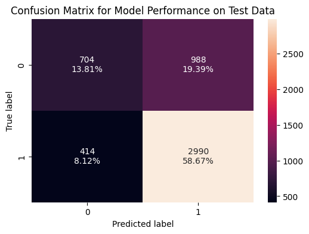

```python
abc1 = AdaBoostClassifier(random_state=42)
abc1_train_perf, abc1_test_perf = build_model(abc1, X_train, y_train, X_test, y_test)
```

🔎 **Observations:** The model demonstrates consistent performance across training and test data, with only a minor decrease in metrics for the test set. This indicates good generalization without significant overfitting, maintaining a balanced trade-off between recall and precision on unseen data.

`2. Oversampled Data`

```
Train Performance:
    Accuracy   Recall  Precision        F1
0  0.744147  0.87792   0.753451  0.810937

---------------------------------

Confusion Matrix for Model Performance on Test Data:

🔎 Observations:

1. True Positives (predicted=1, actual=1): 2965 (58.18%)
2. True Negatives (predicted=0, actual=0): 746 (14.64%)
3. False Positives (predicted=1, actual=0): 946 (18.56%)
4. False Negatives (predicted=0, actual=1): 439 (8.61%)

---------------------------------

Test Performance:
    Accuracy    Recall  Precision        F1
0  0.728218  0.871034   0.758118  0.810663
```

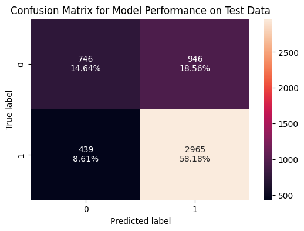

```python
abc1_over=AdaBoostClassifier(random_state=42)
abc1_over_train_perf, abc1_over_test_perf = build_model(abc1_over, X_train_over, y_train_over, X_test, y_test)
```

🔎 **Observations:** The model exhibits consistent performance between training and test data, with only a slight decrease in metrics for the test set. This indicates good generalization without overfitting, maintaining a balanced trade-off between recall and precision across both datasets.

`3. Undersampled Data`

```
Train Performance:
    Accuracy    Recall  Precision        F1
0   0.72686  0.866082   0.740752  0.798529

---------------------------------

Confusion Matrix for Model Performance on Test Data:

🔎 Observations:

1. True Positives (predicted=1, actual=1): 2920 (57.30%)
2. True Negatives (predicted=0, actual=0): 798 (15.66%)
3. False Positives (predicted=1, actual=0): 894 (17.54%)
4. False Negatives (predicted=0, actual=1): 484 (9.50%)

---------------------------------

Test Performance:
    Accuracy    Recall  Precision        F1
0  0.729592  0.857814     0.7656  0.809088
```

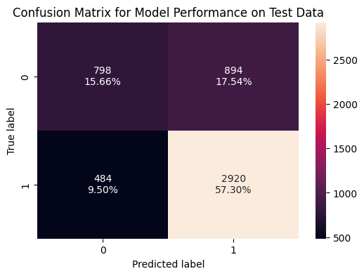

```python
abc1_un=AdaBoostClassifier(random_state=42)
abc1_un_train_perf, abc1_un_test_perf = build_model(abc1_un, X_train_un, y_train_un, X_test, y_test)
```

🔎 **Observations:** The model shows slightly better performance on the test data compared to the training data, with improvements in accuracy, precision, and F1-score. This suggests good generalization without overfitting, and potentially even a slight underfitting on the training data.

##### **Adaboost Classifier Performance Comparison**

```python
# adabost classifier model performance comparison

models_train_comp_df = pd.concat(
    [
        abc1_train_perf.T,
        abc1_test_perf.T,
        abc1_over_train_perf.T,
        abc1_over_test_perf.T,
        abc1_un_train_perf.T,
        abc1_un_test_perf.T,
    ],
    axis=1,
)
models_train_comp_df.columns = [
    "Original Data - Train Perf",
    "Original Data - Test Perf",
    "Oversampled Data - Train Perf",
    "Oversampled Data - Test Perf",
    "Undersampled Data - Train Perf",
    "Undersampled Data - Test Perf",
]
models_train_comp_df
```

|  | Original Data - Train Perf | Original Data - Test Perf | Oversampled Data - Train Perf | Oversampled Data - Test Perf | Undersampled Data - Train Perf | Undersampled Data - Test Perf |
| --- | --- | --- | --- | --- | --- | --- |
| Accuracy | 0.739109 | 0.724882 | 0.744147 | 0.728218 | 0.726860 | 0.729592 |
| Recall | 0.886147 | 0.878378 | 0.877920 | 0.871034 | 0.866082 | 0.857814 |
| Precision | 0.762001 | 0.751634 | 0.753451 | 0.758118 | 0.740752 | 0.765600 |
| F1 | 0.819398 | 0.810079 | 0.810937 | 0.810663 | 0.798529 | 0.809088 |

🔎 **`Observations:`**

1. **Original Data:** The model performs well, with high recall and decent precision, but there is a slight drop in test performance, indicating mild overfitting.
2. **Oversampled Data:** The model maintains a balanced recall and precision, showing stable generalization across train and test sets, making it a reliable choice.
3. **Undersampled Data:** The model has the lowest recall among the three approaches, suggesting it struggles to capture all positive cases, but its precision is slightly higher on the test set.

#### **2. Gradient Boosting Classifier (default)**

`1. Original Data`

```
Train Performance:
    Accuracy    Recall  Precision        F1
0   0.75677  0.876157   0.784737  0.827931

---------------------------------

Confusion Matrix for Model Performance on Test Data:

🔎 Observations:

1. True Positives (predicted=1, actual=1): 2971 (58.30%)
2. True Negatives (predicted=0, actual=0): 810 (15.89%)
3. False Positives (predicted=1, actual=0): 882 (17.31%)
4. False Negatives (predicted=0, actual=1): 433 (8.50%)

---------------------------------

Test Performance:
    Accuracy    Recall  Precision        F1
0  0.741954  0.872797   0.771087  0.818796
```

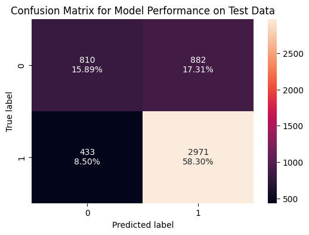

```python
gbc1 = GradientBoostingClassifier(random_state=42)
gbc1_train_perf, gbc1_test_perf = build_model(gbc1, X_train, y_train, X_test, y_test)
```

🔎 **Observations:** The model demonstrates consistent performance across training and test data, with a slight decrease in metrics on the test set. This indicates good generalization without significant overfitting, maintaining a balanced trade-off between recall and precision.

`2. Oversampled Data`

```
Train Performance:
    Accuracy    Recall  Precision        F1
0   0.76274  0.873659   0.775257  0.821522

---------------------------------

Confusion Matrix for Model Performance on Test Data:

🔎 Observations:

1. True Positives (predicted=1, actual=1): 2941 (57.71%)
2. True Negatives (predicted=0, actual=0): 813 (15.95%)
3. False Positives (predicted=1, actual=0): 879 (17.25%)
4. False Negatives (predicted=0, actual=1): 463 (9.09%)

---------------------------------

Test Performance:
    Accuracy    Recall  Precision       F1
0  0.736656  0.863984   0.769895  0.81423
```

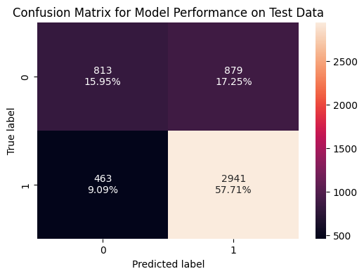

```python
gbc1_over=GradientBoostingClassifier(random_state=42)
gbc1_over_train_perf, gbc1_over_test_perf = build_model(gbc1_over, X_train_over, y_train_over, X_test, y_test)
```

🔎 **Observations:** The model shows good performance on both training and test data, with a slight decrease in metrics for the test set. This indicates effective generalization without significant overfitting, maintaining a balanced trade-off between recall and precision across both datasets.

`3. Undersampled Data`

```
Train Performance:
    Accuracy    Recall  Precision        F1
0  0.741151  0.852876   0.761554  0.804632

---------------------------------

Confusion Matrix for Model Performance on Test Data:

🔎 Observations:

1. True Positives (predicted=1, actual=1): 2873 (56.38%)
2. True Negatives (predicted=0, actual=0): 900 (17.66%)
3. False Positives (predicted=1, actual=0): 792 (15.54%)
4. False Negatives (predicted=0, actual=1): 531 (10.42%)

---------------------------------

Test Performance:
    Accuracy    Recall  Precision        F1
0  0.740385  0.844007   0.783902  0.812845
```

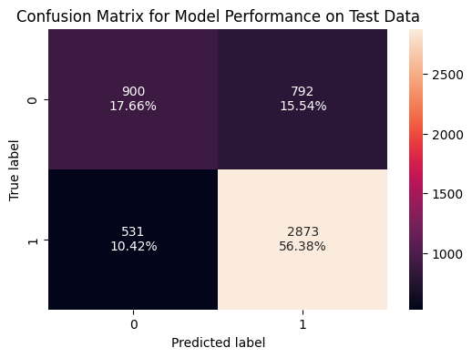

```python
gbc1_un=GradientBoostingClassifier(random_state=42)
gbc1_un_train_perf, gbc1_un_test_perf = build_model(gbc1_un, X_train_un, y_train_un, X_test, y_test)
```

🔎 **Observations:** The model demonstrates consistent performance across training and test data, with slightly better precision and F1-score on the test set. This indicates good generalization without overfitting, and suggests the model may even perform marginally better on unseen data.

##### **Gradient Boosting Classifier Performance Comparison**

```python
# gradient boosting classifier model performance comparison

models_train_comp_df = pd.concat(
    [
        gbc1_train_perf.T,
        gbc1_test_perf.T,
        gbc1_over_train_perf.T,
        gbc1_over_test_perf.T,
        gbc1_un_train_perf.T,
        gbc1_un_test_perf.T,
    ],
    axis=1,
)
models_train_comp_df.columns = [
    "Original Data - Train Perf",
    "Original Data - Test Perf",
    "Oversampled Data - Train Perf",
    "Oversampled Data - Test Perf",
    "Undersampled Data - Train Perf",
    "Undersampled Data - Test Perf",
]
models_train_comp_df
```

|  | Original Data - Train Perf | Original Data - Test Perf | Oversampled Data - Train Perf | Oversampled Data - Test Perf | Undersampled Data - Train Perf | Undersampled Data - Test Perf |
| --- | --- | --- | --- | --- | --- | --- |
| Accuracy | 0.756770 | 0.741954 | 0.762740 | 0.736656 | 0.741151 | 0.740385 |
| Recall | 0.876157 | 0.872797 | 0.873659 | 0.863984 | 0.852876 | 0.844007 |
| Precision | 0.784737 | 0.771087 | 0.775257 | 0.769895 | 0.761554 | 0.783902 |
| F1 | 0.827931 | 0.818796 | 0.821522 | 0.814230 | 0.804632 | 0.812845 |

🔎 **`Observations:`**

1. **Original Data:** The model has good recall and precision, leading to a well-balanced F1 score. The test performance is close to train performance, indicating minimal overfitting.
2. **Oversampled Data:** The model performs slightly worse than the original data, with a minor drop in recall and precision, but still maintains a decent balance between both.
3. **Undersampled Data:** The model has the lowest recall, suggesting it struggles with capturing positive cases, but it has the highest precision on the test set, indicating fewer false positives.

#### **3. XGBoost Classifier (default)**

`1. Original Data`

```
Train Performance:
    Accuracy    Recall  Precision        F1
0   0.83958  0.930513   0.844984  0.885688

---------------------------------

Confusion Matrix for Model Performance on Test Data:

🔎 Observations:

1. True Positives (predicted=1, actual=1): 2910 (57.10%)
2. True Negatives (predicted=0, actual=0): 784 (15.38%)
3. False Positives (predicted=1, actual=0): 908 (17.82%)
4. False Negatives (predicted=0, actual=1): 494 (9.69%)

---------------------------------

Test Performance:
    Accuracy    Recall  Precision        F1
0  0.724882  0.854877   0.762179  0.805871
```

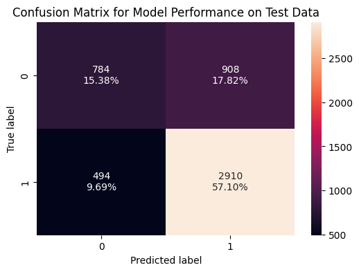

```python
xgb1 = XGBClassifier(random_state=1, eval_metric="logloss")
xgb1_train_perf, xgb1_test_perf = build_model(xgb1, X_train, y_train, X_test, y_test)
```

🔎 **Observations:** The model shows significantly better performance on the training data compared to the test data, with a notable drop in all metrics for the test set. This indicates overfitting, suggesting that the model has learned the training data too well and struggles to generalize effectively to unseen data.

`2. Oversampled Data`

```
Train Performance:
    Accuracy    Recall  Precision        F1
0  0.831558  0.915381   0.831965  0.871682

---------------------------------

Confusion Matrix for Model Performance on Test Data:

🔎 Observations:

1. True Positives (predicted=1, actual=1): 2901 (56.93%)
2. True Negatives (predicted=0, actual=0): 824 (16.17%)
3. False Positives (predicted=1, actual=0): 868 (17.03%)
4. False Negatives (predicted=0, actual=1): 503 (9.87%)

---------------------------------

Test Performance:
    Accuracy    Recall  Precision        F1
0  0.730965  0.852233     0.7697  0.808867
```

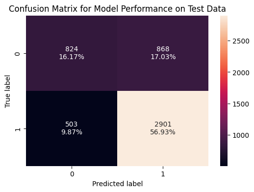

```python
xgb1_over=XGBClassifier(random_state=1, eval_metric="logloss")
xgb1_over_train_perf, xgb1_over_test_perf = build_model(xgb1_over, X_train_over, y_train_over, X_test, y_test)
```

🔎 **Observations:** The model performs well on the training data but shows a noticeable drop in metrics on the test data, indicating slight overfitting. However, the test performance remains reasonable, suggesting the model retains good generalization capabilities.

`3. Undersampled Data`

```
Train Performance:
    Accuracy    Recall  Precision      F1
0   0.82917  0.907383   0.833917  0.8691

---------------------------------

Confusion Matrix for Model Performance on Test Data:

🔎 Observations:

1. True Positives (predicted=1, actual=1): 2782 (54.59%)
2. True Negatives (predicted=0, actual=0): 869 (17.05%)
3. False Positives (predicted=1, actual=0): 823 (16.15%)
4. False Negatives (predicted=0, actual=1): 622 (12.21%)

---------------------------------

Test Performance:
    Accuracy    Recall  Precision        F1
0  0.716444  0.817274   0.771706  0.793836
```

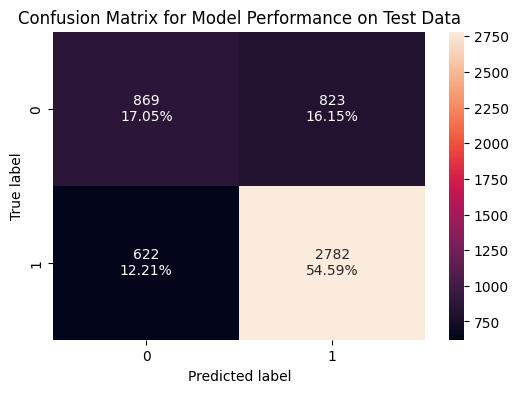

```python
xgb1_un=XGBClassifier(random_state=1, eval_metric="logloss")
xgb1_un_train_perf, xgb1_un_test_perf = build_model(xgb1_un, X_train_un, y_train_un, X_test, y_test)
```

🔎 **Observations:** The model demonstrates strong performance on the training data but experiences a significant drop in all metrics on the test data, indicating overfitting. This suggests that while the model learns the training set well, it struggles to generalize effectively to unseen data.

```python
# xgboost classifier performance comparison
models_test_comp_df = pd.concat(
    [
        xgb1_train_perf.T,
        xgb1_test_perf.T,
        xgb1_over_train_perf.T,
        xgb1_over_test_perf.T,
        xgb1_un_train_perf.T,
        xgb1_un_test_perf.T,
    ],
    axis=1,
)
models_test_comp_df.columns = [
    "Original Data - Train Perf",
    "Original Data - Test Perf",
    "Oversampled Data - Train Perf",
    "Oversampled Data - Test Perf",
    "Undersampled Data - Train Perf",
    "Undersampled Data - Test Perf",
]
models_test_comp_df
```

|  | Original Data - Train Perf | Original Data - Test Perf | Oversampled Data - Train Perf | Oversampled Data - Test Perf | Undersampled Data - Train Perf | Undersampled Data - Test Perf |
| --- | --- | --- | --- | --- | --- | --- |
| Accuracy | 0.839580 | 0.724882 | 0.831558 | 0.730965 | 0.829170 | 0.716444 |
| Recall | 0.930513 | 0.854877 | 0.915381 | 0.852233 | 0.907383 | 0.817274 |
| Precision | 0.844984 | 0.762179 | 0.831965 | 0.769700 | 0.833917 | 0.771706 |
| F1 | 0.885688 | 0.805871 | 0.871682 | 0.808867 | 0.869100 | 0.793836 |

🔎 **`Observations:`**

#### 🏆 **Performance Analysis of Boosting Models**

1️⃣ **Gradient Boosting performed the best overall:**

2️⃣ **XGBoost had the best train performance but lower test performance:**

- Exhibited signs of overfitting, performing significantly better on training data than test data.
- Oversampling improved its stability slightly, but it still lagged behind Gradient Boosting in test performance.

3️⃣ **AdaBoost showed balanced but slightly lower performance:**

- Maintained consistent results across different sampling techniques.
- Performed best on **Oversampled Data**, making it a viable option for handling class imbalance.

##### 🚀 **Next Steps: Fine-tuning Boosting Models**

✅ **Optimize AdaBoost using Oversampled Data**  
✅ **Tune Gradient Boosting on Original Data**  
✅ **Refine XGBoost with Oversampled Data to address overfitting**

### `1. Tuned AdaBoost Classifier on Oversampled Data`

```
Fitting 5 folds for each of 30 candidates, totalling 150 fits
Best Parameters: {'n_estimators': 50, 'learning_rate': 0.01, 'estimator': DecisionTreeClassifier(class_weight='balanced', max_depth=2)}

---------------------------------

Mean cross-validation f1 score: 0.7974348236659233

---------------------------------

Train Performance:
    Accuracy    Recall  Precision        F1
0  0.717703  0.890848   0.722292  0.797764

---------------------------------

Confusion Matrix for Model Performance on Test Data:

🔎 Observations:

1. True Positives (predicted=1, actual=1): 3015 (59.16%)
2. True Negatives (predicted=0, actual=0): 657 (12.89%)
3. False Positives (predicted=1, actual=0): 1035 (20.31%)
4. False Negatives (predicted=0, actual=1): 389 (7.63%)

---------------------------------

Test Performance:
    Accuracy    Recall  Precision        F1
0  0.720565  0.885723   0.744444  0.808962
```

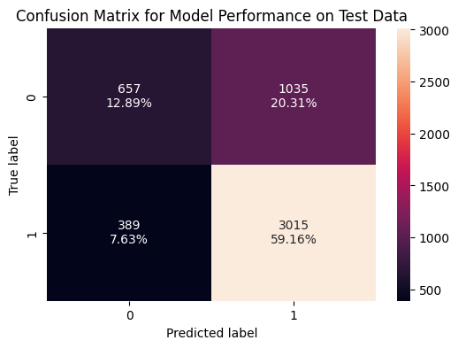

```python
# Define hyperparameter grid
param_dict = {
    'n_estimators': [50, 100, 200, 300],
    'learning_rate': [0.01, 0.05, 0.1, 0.2],
    'estimator': [DecisionTreeClassifier(max_depth=d, class_weight="balanced") for d in [1, 2, 3, 5]]
}

# Initialize model
ada_model = AdaBoostClassifier(random_state=42)
tuned_ada_results = tune_model(param_dict, skfold, ada_model, X_train_over, y_train_over, X_test, y_test, scoring='f1', n_iter=30)
ada_random_train_perf = tuned_ada_results['train_performance']
ada_random_test_perf = tuned_ada_results['test_performance']
```

🔎 **Observations:** The test F1 score is grater than the cross-validation mean F1 score, indicating that the model generalizes well. The accuracy of the train set and test set are close, suggesting that the model generalizes well without significant overfitting or underfitting.

### `2. Tuned Gradient Boosting on Original Data`

```
Fitting 5 folds for each of 30 candidates, totalling 150 fits
Best Parameters: {'subsample': 0.8, 'n_estimators': 50, 'min_samples_split': 10, 'min_samples_leaf': 1, 'max_depth': 3, 'learning_rate': 0.1}

---------------------------------

Mean cross-validation f1 score: 0.8244376829981415

---------------------------------

Train Performance:
    Accuracy    Recall  Precision        F1
0  0.753876  0.877626   0.780966  0.826479

---------------------------------

Confusion Matrix for Model Performance on Test Data:

🔎 Observations:

1. True Positives (predicted=1, actual=1): 2973 (58.34%)
2. True Negatives (predicted=0, actual=0): 812 (15.93%)
3. False Positives (predicted=1, actual=0): 880 (17.27%)
4. False Negatives (predicted=0, actual=1): 431 (8.46%)

---------------------------------

Test Performance:
    Accuracy    Recall  Precision        F1
0  0.742739  0.873384   0.771607  0.819347
```

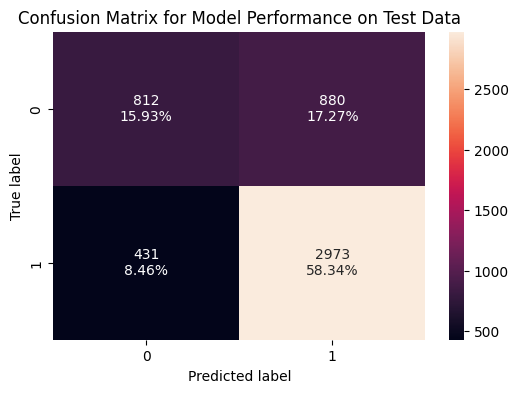

```python
# Define hyperparameter grid
param_dict = {
    'n_estimators': [50, 100, 200, 300],  # Number of boosting stages
    'learning_rate': [0.01, 0.05, 0.1, 0.2],  # Controls step size
    'max_depth': [3, 5, 7],  # Depth of trees
    'subsample': [0.6, 0.8, 1.0],  # Fraction of samples used per tree
    'min_samples_split': [2, 5, 10],  # Minimum samples required to split a node
    'min_samples_leaf': [1, 2, 4]  # Minimum samples per leaf node
}

# Initialize model
gb_model = GradientBoostingClassifier(random_state=42)
tuned_gb_results = tune_model(param_dict, skfold, gb_model, X_train, y_train, X_test, y_test, scoring='f1', n_iter=30)
gb_random_train_perf = tuned_gb_results['train_performance']
gb_random_test_perf = tuned_gb_results['test_performance']
```

🔎 **Observations:** The test F1 score is closer to the cross-validation mean F1 score, indicating that the model generalizes well. The accuracy of the train set and test set are close, suggesting that the model generalizes well without significant overfitting or underfitting.

### `3. Tuned XGBoost Classifier on Oversampled Data`

```
Fitting 5 folds for each of 30 candidates, totalling 150 fits
Best Parameters: {'subsample': 1.0, 'n_estimators': 100, 'min_samples_split': 5, 'min_samples_leaf': 4, 'max_depth': 5, 'learning_rate': 0.1}

---------------------------------

Mean cross-validation f1 score: 0.8187892217919968

---------------------------------

Train Performance:
    Accuracy    Recall  Precision        F1
0  0.775135  0.880491   0.785621  0.830355

---------------------------------

Confusion Matrix for Model Performance on Test Data:

🔎 Observations:

1. True Positives (predicted=1, actual=1): 2951 (57.91%)
2. True Negatives (predicted=0, actual=0): 825 (16.19%)
3. False Positives (predicted=1, actual=0): 867 (17.01%)
4. False Negatives (predicted=0, actual=1): 453 (8.89%)

---------------------------------

Test Performance:
    Accuracy    Recall  Precision        F1
0  0.740973  0.866921   0.772918  0.817225
```

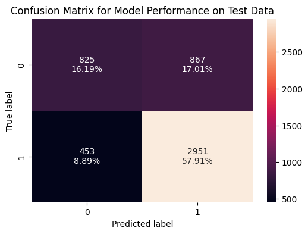

```python
# Define hyperparameter grid
xgb_params = {
    'n_estimators': [100, 200, 300, 400],
    'learning_rate': [0.01, 0.05, 0.1, 0.2],
    'max_depth': [3, 5, 7, 9],
    'subsample': [0.6, 0.8, 1.0],
    'colsample_bytree': [0.6, 0.8, 1.0],  # Fraction of features used per tree
    'gamma': [0, 0.1, 0.2, 0.5],  # Minimum loss reduction for a split
    'reg_lambda': [0.1, 1, 10]  # L2 regularization
}

# Initialize model
xgb_model = XGBClassifier(use_label_encoder=False, eval_metric='logloss', random_state=42)
tuned_xgb_results = tune_model(param_dict, skfold, xgb_model, X_train_over, y_train_over, X_test, y_test, scoring='f1', n_iter=30)
xgb_random_train_perf = tuned_xgb_results['train_performance']
xgb_random_test_perf = tuned_xgb_results['test_performance']
```

🔎 **Observations:** The test F1 score is almost equal to the cross-validation mean F1 score, indicating that the model generalizes well. The accuracy of the train set and test set are close, suggesting that the model generalizes well without significant overfitting or underfitting.

### `Tuned Model Performance`

```python
# tuned model performance comparison

models_train_test_comp_df = pd.concat(
    [ada_random_train_perf.T,
     ada_random_test_perf.T,
     gb_random_train_perf.T,
     gb_random_test_perf.T,
     xgb_random_train_perf.T,
     xgb_random_test_perf.T],
     axis=1
)

models_train_test_comp_df.columns = [
    "Tuned AdaBoost Train Perf",
    "Tuned AdaBoost Test Perf",
    "Tuned Gradient Boost Train Perf",
    "Tuned Gradient Boost Test Perf",
    "Tuned XGBoost Train Perf",
    "Tuned XGBoost Test Perf",
]

models_train_test_comp_df
```

|  | Tuned AdaBoost Train Perf | Tuned AdaBoost Test Perf | Tuned Gradient Boost Train Perf | Tuned Gradient Boost Test Perf | Tuned XGBoost Train Perf | Tuned XGBoost Test Perf |
| --- | --- | --- | --- | --- | --- | --- |
| Accuracy | 0.717703 | 0.720565 | 0.753876 | 0.742739 | 0.775135 | 0.740973 |
| Recall | 0.890848 | 0.885723 | 0.877626 | 0.873384 | 0.880491 | 0.866921 |
| Precision | 0.722292 | 0.744444 | 0.780966 | 0.771607 | 0.785621 | 0.772918 |
| F1 | 0.797764 | 0.808962 | 0.826479 | 0.819347 | 0.830355 | 0.817225 |

### 🚀 **Performance Evaluation of Tuned Boosting Models**

#### **1️⃣ Tuned AdaBoost Performance**

- The model has **high recall** but lower precision, leading to more false positives.
- The F1 score on test data is very close to the cross-validation F1 score, confirming **good generalization** but **lower overall performance** than other boosting models.
- Slight **underfitting**, making it stable but less optimal.

#### **2️⃣ Tuned Gradient Boosting Performance**

- **Well-balanced precision and recall**, contributing to strong classification performance.
- The F1 score on test data closely matches the cross-validation F1 score, suggesting **excellent generalization**.
- Performs **better than AdaBoost** and **slightly better than XGBoost** in terms of overall stability.

#### **3️⃣ Tuned XGBoost Performance**

- Has the **highest training F1-score** but a slightly lower test F1-score compared to Gradient Boosting.
- The cross-validation F1 score is slightly lower than that of Gradient Boosting, indicating **slightly higher overfitting**.
- Still **a strong contender** due to its competitive performance.

### **📌 Final Boosting Model Selection**

✅ **Gradient Boosting is the best choice** due to its **strong generalization and balanced metrics**.  
✅ **XGBoost is a close second**, offering slightly better training performance but with **a minor overfitting risk**.

## 🌟 **Final Model Selection** 🌟

```python
models_train_comp_df = pd.concat(
    [random_search1_train_perf.T,
     random_search2_train_perf.T,
     random_search3_train_perf.T,
     ada_random_train_perf.T,
     gb_random_train_perf.T,
     xgb_random_train_perf.T],
     axis=1
)

models_train_comp_df.columns = [
    "Tuned Decision Tree Train Perf",
    "Tuned Bagging Classifier Train Perf",
    "Tuned Random Forest Classifier Train Perf",
    "Tuned AdaBoost Train Perf",
    "Tuned Gradient Boost Train Perf",
    "Tuned XGBoost Train Perf",
]

models_train_comp_df
```

|  | Tuned Decision Tree Train Perf | Tuned Bagging Classifier Train Perf | Tuned Random Forest Classifier Train Perf | Tuned AdaBoost Train Perf | Tuned Gradient Boost Train Perf | Tuned XGBoost Train Perf |
| --- | --- | --- | --- | --- | --- | --- |
| Accuracy | 0.717611 | 0.740777 | 0.758880 | 0.717703 | 0.753876 | 0.775135 |
| Recall | 0.891215 | 0.880050 | 0.890480 | 0.890848 | 0.877626 | 0.880491 |
| Precision | 0.722073 | 0.766441 | 0.779765 | 0.722292 | 0.780966 | 0.785621 |
| F1 | 0.797778 | 0.819326 | 0.831453 | 0.797764 | 0.826479 | 0.830355 |

```python
models_test_comp_df = pd.concat(
    [random_search1_test_perf.T,
     random_search2_test_perf.T,
     random_search3_test_perf.T,
     ada_random_test_perf.T,
     gb_random_test_perf.T,
     xgb_random_test_perf.T],
     axis=1
)

models_test_comp_df.columns = [
    "Tuned Decision Tree Test Perf",
    "Tuned Bagging Classifier Test Perf",
    "Tuned Random Forest Classifier Test Perf",
    "Tuned AdaBoost Test Perf",
    "Tuned Gradient Boost Test Perf",
    "Tuned XGBoost Test Perf",
]

models_test_comp_df
```

|  | Tuned Decision Tree Test Perf | Tuned Bagging Classifier Test Perf | Tuned Random Forest Classifier Test Perf | Tuned AdaBoost Test Perf | Tuned Gradient Boost Test Perf | Tuned XGBoost Test Perf |
| --- | --- | --- | --- | --- | --- | --- |
| Accuracy | 0.720761 | 0.728414 | 0.738030 | 0.720565 | 0.742739 | 0.740973 |
| Recall | 0.886016 | 0.870153 | 0.882491 | 0.885723 | 0.873384 | 0.866921 |
| Precision | 0.744508 | 0.758709 | 0.762630 | 0.744444 | 0.771607 | 0.772918 |
| F1 | 0.809121 | 0.810619 | 0.818194 | 0.808962 | 0.819347 | 0.817225 |

### 🚀 **Comparison of Model Performance**

We compare the models based on **accuracy, recall, precision, and F1-score**, with a primary focus on **F1-score** to balance precision and recall. Additionally, we consider the **mean cross-validation F1-score** to assess generalization.

#### **🎯 2️⃣ Recall Comparison (Higher is Better for Sensitivity)**

🔎 **`Observations:`**

- **Decision Tree and AdaBoost have the highest recall,** but this comes at the cost of lower precision.
- **Random Forest also maintains high recall while slightly improving precision, making it a strong contender.**
- **Bagging, Gradient Boosting, and XGBoost show more balanced recall and precision trade-offs.**

#### **📈 4️⃣ F1-Score Comparison (Primary Metric for Evaluation)**

#### **Mean Cross-Validation F1-Scores**

| Model | CV F1-Score |
| --- | --- |
| Decision Tree | 0.7959 |
| Bagging Classifier | 0.8180 |
| Random Forest | 0.8251 |
| AdaBoost | 0.7974 |
| Gradient Boosting | 0.8244 |
| XGBoost | 0.8188 |

🔎 **`Observations:`**

- **Gradient Boosting has the highest test F1-score, making it the most balanced model.**
- **Random Forest has the highest cross-validation F1-score, but it also overfits more than Gradient Boosting.**
- **XGBoost and Gradient Boosting are close competitors, but Gradient Boosting generalizes slightly better.**
- **Bagging Classifier performs well and generalizes better than Decision Tree and AdaBoost.**

#### **🏆 Final Model Selection**

✅ **Best Overall Model: `Gradient Boosting`**

- **Achieves the best balance between precision and recall.**
- **Minimal overfitting compared to Random Forest and XGBoost.**
- **Consistently strong across train, test, and cross-validation scores.**

📌 **Alternative Choices:**

- **`XGBoost`**: Strong performer, slightly more overfitting than Gradient Boosting.
- **`Random Forest`**: Highest cross-validation score but more prone to overfitting.
- **`Bagging Classifier`**: A more stable option than Decision Tree but slightly weaker than boosting models.

**Final Recommendation:** Use **Gradient Boosting** as the primary mode. 🚀

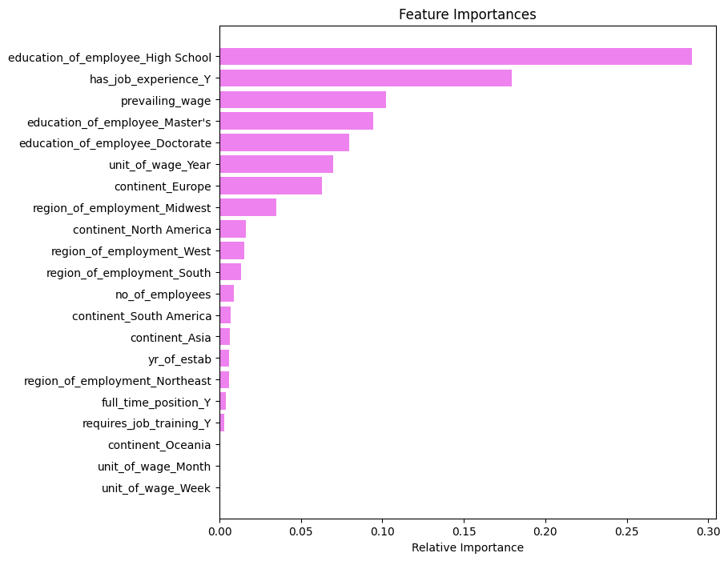

```python
# importance of features
best_model = tuned_gb_results['best_model'].best_estimator_

feature_names = X_train.columns
importances = best_model.feature_importances_
indices = np.argsort(importances)

plt.figure(figsize=(8, 8))
plt.title("Feature Importances")
plt.barh(range(len(indices)), importances[indices], color="violet", align="center")
plt.yticks(range(len(indices)), [feature_names[i] for i in indices])
plt.xlabel("Relative Importance")
plt.show()
```

## 🌟 **Actionable Insights & Recommendations** 🌟

### **Recommendations**

1. **Enhance Education-Based Hiring Strategies**:
   - Employers should prioritize hiring candidates with higher education levels (e.g., Master's or Doctorate degrees) for specialized roles.
   - Offer skill development programs for candidates with only High School education to improve their employability.
2. **Prioritize Experienced Candidates**:
   - Focus on hiring candidates with relevant job experience for roles requiring immediate expertise.
   - For less experienced candidates, create internship or training programs to build their skills.
3. **Offer Competitive Wages**:
   - Employers should ensure that wage offerings align with or exceed market standards to attract skilled talent and improve visa approval rates.
   - Conduct regular wage benchmarking to stay competitive.
4. **Leverage Regional Trends**:
   - Expand operations or hiring efforts in regions like the Midwest and South, which show favorable employment trends.
   - Investigate challenges in regions like the Northeast and address any barriers to approvals.
5. **Focus on Continental Support**:
   - Provide targeted support for applicants from continents like Asia and South America, where visa approvals may face challenges (e.g., documentation issues or insufficient qualifications).
6. **Streamline Full-Time Roles**:
   - Encourage full-time positions for roles requiring long-term commitment while maintaining flexibility for part-time opportunities where applicable.

### **Conclusion and Business Recommendations**

1. **Model Selection**:  
   The Gradient Boosting model was chosen as it provides reliable predictions with balanced precision, recall, and F1-score on test data.
2. **Key Factors Influencing Approvals**:  
   Education level, job experience, prevailing wages, regional trends, and continental influences are critical drivers of visa approvals.
3. **Business Growth Strategies**:
   - Focus on hiring highly educated and experienced candidates while offering competitive wages to attract top talent.
   - Expand operations in regions with favorable employment trends (e.g., Midwest, South) while addressing challenges in regions like the Northeast.
   - Provide targeted support for applicants from continents like Asia and South America to improve their success rates.
   - Invest in training programs for less experienced applicants to build a skilled workforce.